# Project - AllLife Bank Customer Segmentation

### Cophenetic Correlation Analysis

##### *Click to return to TOC*

- Using Cophenetic correlation to compare the dendrograms

#### Using Distance Metrics - "chebyshev", "mahalanobis", "cityblock" (Manhattan) & corresponding linkage methods

```python
# list of distance metrics
distance_metrics = ["chebyshev", "mahalanobis", "cityblock"]

# list of linkage methods
linkage_methods = ["single", "complete", "average", "weighted"]

compare = []

high_cophenet_corr = 0
high_dm_lm = [0, 0]

for dm in distance_metrics:
    for lm in linkage_methods:
        Z = linkage(subset_scaled_df, metric=dm, method=lm)
        c, coph_dists = cophenet(Z, pdist(subset_scaled_df))
        print(
            "Cophenetic correlation for {} distance and {} linkage is {}.".format(
                dm.capitalize(), lm, c
            )
        )
        if high_cophenet_corr < c:
            high_cophenet_corr = c
            high_dm_lm[0] = dm
            high_dm_lm[1] = lm

        compare.append([dm + " - " + lm, c])
```

```
Cophenetic correlation for Chebyshev distance and single linkage is 0.7379112982920528.
Cophenetic correlation for Chebyshev distance and complete linkage is 0.8578617029322211.
Cophenetic correlation for Chebyshev distance and average linkage is 0.8960370054789858.
Cophenetic correlation for Chebyshev distance and weighted linkage is 0.893309534644998.
Cophenetic correlation for Mahalanobis distance and single linkage is 0.7054746377393304.
Cophenetic correlation for Mahalanobis distance and complete linkage is 0.6513369047977703.
Cophenetic correlation for Mahalanobis distance and average linkage is 0.833028569226309.
Cophenetic correlation for Mahalanobis distance and weighted linkage is 0.784329595177624.
Cophenetic correlation for Cityblock distance and single linkage is 0.7253931237436752.
Cophenetic correlation for Cityblock distance and complete linkage is 0.8741048470104825.
Cophenetic correlation for Cityblock distance and average linkage is 0.8960391624288154.
Cophenetic correlation for Cityblock distance and weighted linkage is 0.8804995247359442.
```

```python
# printing the combination of distance metric and linkage method with the highest cophenetic correlation
print(
    "Highest cophenetic correlation is {}, which is obtained with {} distance and {} linkage.".format(
        high_cophenet_corr, high_dm_lm[0].capitalize(), high_dm_lm[1]
    )
)
```

```
Highest cophenetic correlation is 0.8960391624288154, which is obtained with Cityblock distance and average linkage.
```

#### Using Distance Metrics - "euclidean" & corresponding linkage methods

```python
# list of linkage methods
linkage_methods = ["single", "complete", "average", "centroid", "ward", "weighted"]

high_cophenet_corr = 0
high_dm_lm = [0, 0]

for lm in linkage_methods:
    Z = linkage(subset_scaled_df, metric="euclidean", method=lm)
    c, coph_dists = cophenet(Z, pdist(subset_scaled_df))
    print("Cophenetic correlation for {} linkage is {}.".format(lm, c))
    compare.append(["euclidean - " + lm, c])
    if high_cophenet_corr < c:
        high_cophenet_corr = c
        high_dm_lm[0] = "euclidean"
        high_dm_lm[1] = lm
```

```
Cophenetic correlation for single linkage is 0.7395135051413775.
Cophenetic correlation for complete linkage is 0.8794736468795109.
Cophenetic correlation for average linkage is 0.8974425535306298.
Cophenetic correlation for centroid linkage is 0.894471288720818.
Cophenetic correlation for ward linkage is 0.7425813590948763.
Cophenetic correlation for weighted linkage is 0.8551098644586315.
```

```python
# printing the combination of distance metric and linkage method with the highest cophenetic correlation
print(
    "Highest cophenetic correlation is {}, which is obtained with {} linkage.".format(
        high_cophenet_corr, high_dm_lm[1]
    )
)
```

```
Highest cophenetic correlation is 0.8974425535306298, which is obtained with average linkage.
```

```python
# lists to save results of cophenetic correlation calculation
compare_cols = ["Linkage", "Cophenetic Coefficient"]

# let's create a dataframe to compare cophenetic correlations for each linkage method
df_cc = pd.DataFrame(compare, columns=compare_cols)
df_cc.sort_values(by='Cophenetic Coefficient',inplace=True, ascending=False)
df_cc
```

|  | Linkage | Cophenetic Coefficient |
| --- | --- | --- |
| 14 | euclidean - average | 0.897443 |
| 10 | cityblock - average | 0.896039 |
| 2 | chebyshev - average | 0.896037 |
| 15 | euclidean - centroid | 0.894471 |
| 3 | chebyshev - weighted | 0.893310 |
| 11 | cityblock - weighted | 0.880500 |
| 13 | euclidean - complete | 0.879474 |
| 9 | cityblock - complete | 0.874105 |
| 1 | chebyshev - complete | 0.857862 |
| 17 | euclidean - weighted | 0.855110 |
| 6 | mahalanobis - average | 0.833029 |
| 7 | mahalanobis - weighted | 0.784330 |
| 16 | euclidean - ward | 0.742581 |
| 12 | euclidean - single | 0.739514 |
| 0 | chebyshev - single | 0.737911 |
| 8 | cityblock - single | 0.725393 |
| 4 | mahalanobis - single | 0.705475 |
| 5 | mahalanobis - complete | 0.651337 |

**Observations**

- We see that the cophenetic correlation is maximum with with Euclidean distance and average linkage

### Dendogram Visualizations

*Click to return to TOC*

#### Visualizing Dendrograms for different linkage methods using Euclidean metric

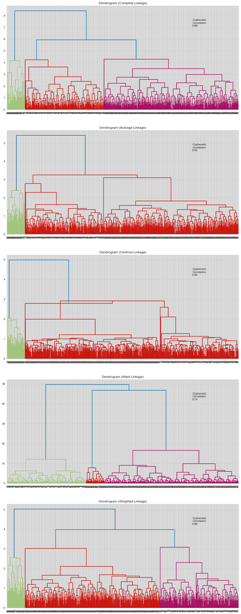

```python
# list of linkage methods
linkage_methods = ["complete", "average", "centroid", "ward", "weighted"]

# to create a subplot image
fig, axs = plt.subplots(len(linkage_methods), 1, figsize=(15, 40))

# We will enumerate through the list of linkage methods above
# For each linkage method, we will plot the dendrogram and calculate the cophenetic correlation
for i, method in enumerate(linkage_methods):
    Z = linkage(subset_scaled_df, metric="euclidean", method=method)

    dendrogram(Z, ax=axs[i])
    axs[i].set_title(f"Dendrogram ({method.capitalize()} Linkage)")

    coph_corr, coph_dist = cophenet(Z, pdist(subset_scaled_df))
    axs[i].annotate(
        f"Cophenetic\nCorrelation\n{coph_corr:0.2f}",
        (0.80, 0.80),
        xycoords="axes fraction",
    )
```

**Observations**

- The Cophenetic correlation using Euclidean metric is highest for Average, Centroid and Complete linkage methods
- Comparing the Dendograms of the Euclidean metric, though the Cophenetic Coefficient is low for Ward linkage, we see the Ward linkage to have stable homogenous clusters with more variability and distinct clusters compared with the other linkages
- 3 seems to be an appropriate number of clusters from the dendogram for Ward linkage

#### Visualizing Dendrograms for Average linkage methods using Chebyshev & Cityblock metric since they had high Cophenetic Coefficient values

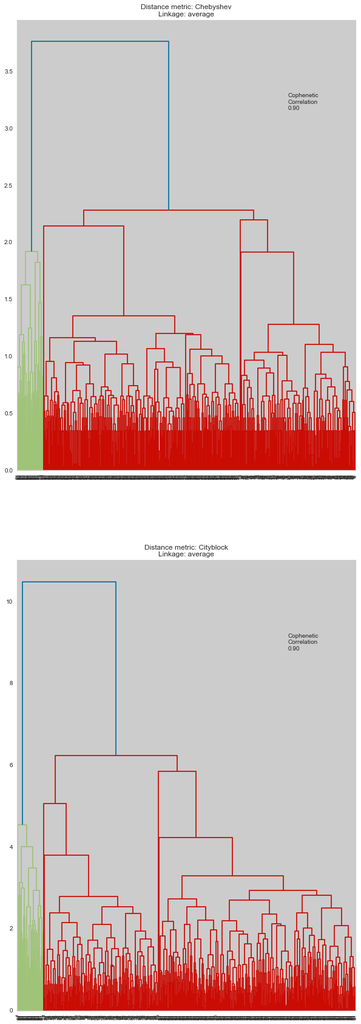

```python
# list of distance metrics
distance_metrics = ["chebyshev", "cityblock"]

# list of linkage methods
linkage_methods = ["average"]

# to create a subplot image
fig, axs = plt.subplots(2, 1, figsize=(10, 30)
)

i = 0
for dm in distance_metrics:
    for lm in linkage_methods:
        Z = linkage(subset_scaled_df, metric=dm, method=lm)

        dendrogram(Z, ax=axs[i])
        axs[i].set_title("Distance metric: {}\nLinkage: {}".format(dm.capitalize(), lm))

        coph_corr, coph_dist = cophenet(Z, pdist(subset_scaled_df))
        axs[i].annotate(
            f"Cophenetic\nCorrelation\n{coph_corr:0.2f}",
            (0.80, 0.80),
            xycoords="axes fraction",
        )
        i += 1
```

**Observations**

- The Dendograms for the Chebyshev & Cityblock metric with Average does not seem to have distinct clusters as compared with the Ward linkage of Euclidean metric and have overlapping tree clusters

#### Validating the Hierarchical Clustering for Ward linkage with Euclidean to identify best Cluster profiling

- 3 would be an appropriate number of the clusters from the dendrogram for Euclidean metric with Ward linkage
- We will do a quick validation using the Hierarchical Clustering to verify the cluster segments

```python
for i in range (2, 6 , 1):
    print("Index - " + str(i));
    HCmodel = AgglomerativeClustering(n_clusters=i, affinity="euclidean", linkage="ward")
    HCmodel.fit(subset_scaled_df)
    subset_scaled_df["HC_Clusters"] = HCmodel.labels_
    dfHC["HC_Clusters"] = HCmodel.labels_
    print(dfHC["HC_Clusters"].value_counts())
    for cl in dfHC["HC_Clusters"].unique():
        print("Total_Credit_Cards -> ", dfHC[dfHC["HC_Clusters"] == cl]["Total_Credit_Cards"].unique())
```

```
Index - 2
0    427
1    222
Name: HC_Clusters, dtype: int64
Total_Credit_Cards ->  [ 2  7  5  6  4  9  8 10]
Total_Credit_Cards ->  [3 2 4 1 5]
Index - 3
0    377
1    222
2     50
Name: HC_Clusters, dtype: int64
Total_Credit_Cards ->  [2 7 5 4 6]
Total_Credit_Cards ->  [3 2 4 1 5]
Total_Credit_Cards ->  [ 6  5  9  8 10  7]
Index - 4
0    222
3    195
1    182
2     50
Name: HC_Clusters, dtype: int64
Total_Credit_Cards ->  [2 7 5 6 4]
Total_Credit_Cards ->  [3 2 4 1 5]
Total_Credit_Cards ->  [ 6  5  9  8 10  7]
Total_Credit_Cards ->  [4 5 6 7]
Index - 5
1    195
0    182
4    120
3    102
2     50
Name: HC_Clusters, dtype: int64
Total_Credit_Cards ->  [2 7 5 6 4]
Total_Credit_Cards ->  [3 4 1 2]
Total_Credit_Cards ->  [ 6  5  9  8 10  7]
Total_Credit_Cards ->  [3 2 4 1 5]
Total_Credit_Cards ->  [4 5 6 7]
```

**Observations**

- 3 would be the appropriate number of the clusters from the dendrogram with Ward linkage method